# DIGPD_Preprocessing

## PCA on normalized and probe-filtered data

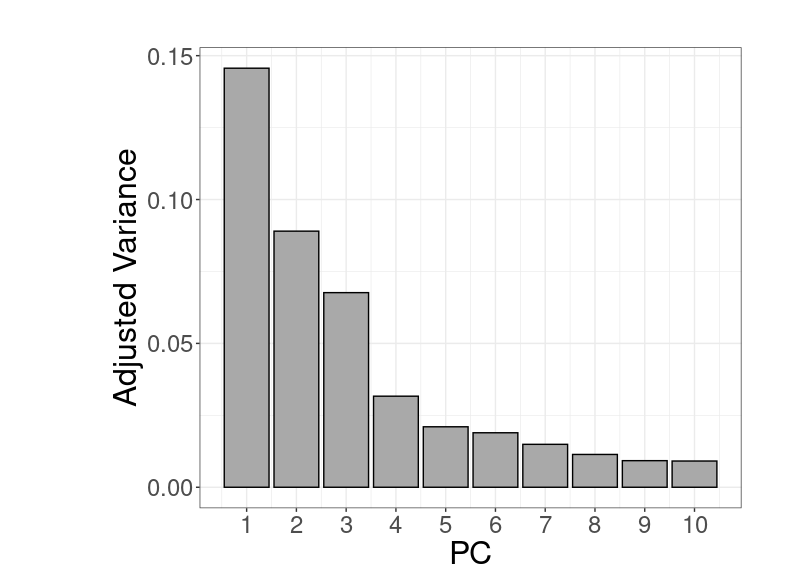

PCA on normalized and filtered data - scree

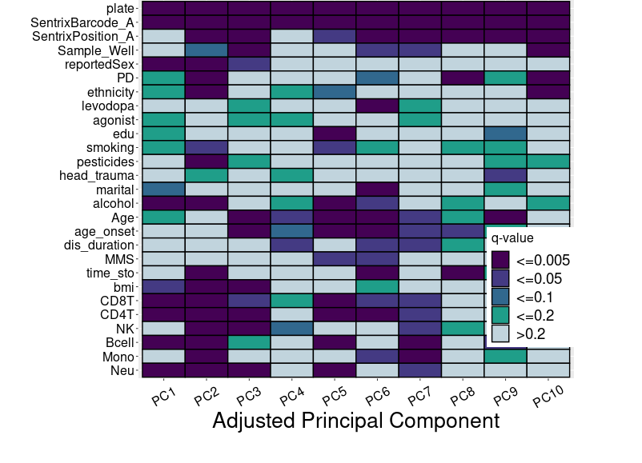

PCA on normalized and filtered data - heat map

```r
betas_norm <- getBeta(DIGPD_RG_filtered)
all.equal(colnames(betas_norm), rownames(meta_categorical)) #TRUE

#PCA on beta values: input
PCA_full<-princomp(betas_norm[complete.cases(betas_norm),])

PCA_Plot(PCA_full, type="sparse", MTC=T, Discrete=T)
```

## Females PCA

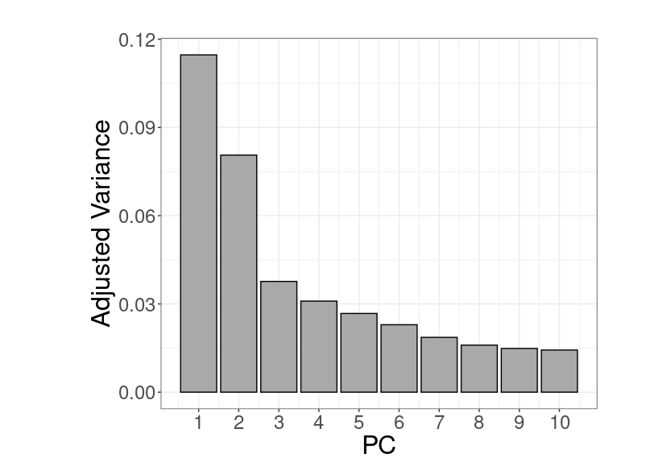

PCA scree plot for females: normalized, uncorrected data

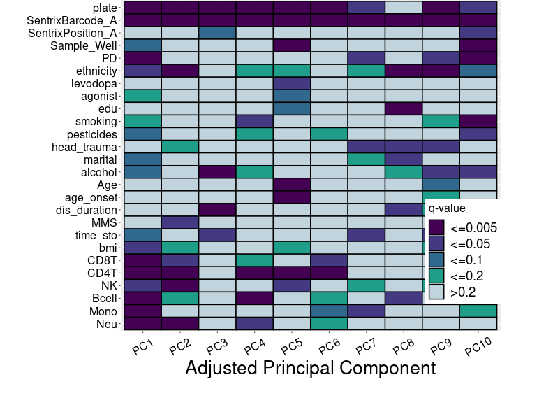

PCA heat map for females: normalized, uncorrected data

```r
betas_norm_F <- getBeta(DIGPD_RG_filtered[,sampleNames(DIGPD_RG_filtered) %in% meta_F$Sample_Name])
all.equal(colnames(betas_norm_F), rownames(meta_F)) #TRUE

#PCA on beta values: input
PCA_full<-princomp(betas_norm_F[complete.cases(betas_norm_F),])
meta_categorical <- meta_F[,c("plate", "SentrixBarcode_A", "SentrixPosition_A", "Sample_Well", "PD", "ethnicity", "levodopa", "agonist", "edu", "smoking", "pesticides", "head_trauma", "marital", "alcohol")]
meta_continuous <- meta_F[,c("Age", "age_onset", "dis_duration","MMS", "time_sto", "bmi", "CD8T", "CD4T", "NK", "Bcell", "Mono", "Neu")]
ord <- c(seq(1:(ncol(meta_categorical)+ncol(meta_continuous))))
PCA_Plot(PCA_full, type="Sparse", MTC=T, Discrete=T)
```

## Males PCA

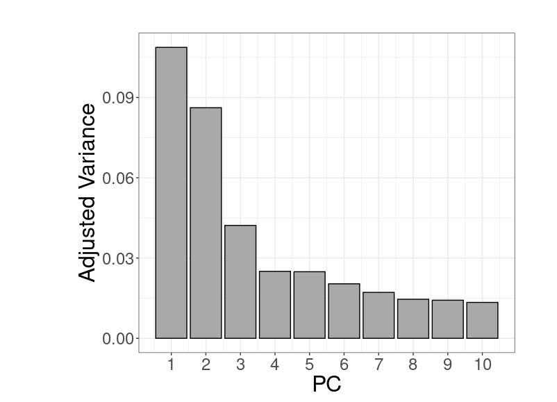

PCA scree plot for males: normalized, uncorrected data

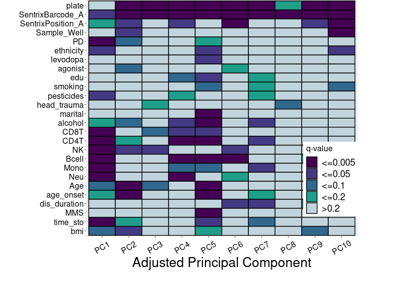

PCA heat map for males: normalized, uncorrected data

```r
betas_norm_M <- getBeta(DIGPD_RG_filtered[,sampleNames(DIGPD_RG_filtered) %in% meta_M$Sample_Name])
all.equal(colnames(betas_norm_M), rownames(meta_M)) #TRUE

#PCA on beta values: input
PCA_full<-princomp(betas_norm_M[complete.cases(betas_norm_M),])
meta_categorical <- meta_M[,c("plate", "SentrixBarcode_A", "SentrixPosition_A", "Sample_Well", "PD", "ethnicity", "levodopa", "agonist", "edu", "smoking", "pesticides", "head_trauma", "marital", "alcohol","CD8T", "CD4T", "NK", "Bcell", "Mono", "Neu")]
meta_continuous <- meta_M[,c("Age", "age_onset", "dis_duration","MMS", "time_sto", "bmi")]
ord <- c(seq(1:(ncol(meta_categorical)+ncol(meta_continuous))))
PCA_Plot(PCA_full, type="Sparse", MTC=T, Discrete=T)
```

## Checking sex balancing by batch

Amy Inkster advised that if sex is balanced across batches, this step can be applied on all the data.

```r
table(digpd_meta$reportedSex, digpd_meta$plate)
#     1  2  3  4  5  6  7
#  F 37 36 34 35 27  0  0
#  M 39 44 35 38 41 46 13
# majority of plates, except 2, are balanced

table(digpd_meta$reportedSex, digpd_meta$SentrixBarcode_A)
#majority of chips are balanced between sexes

table(digpd_meta$reportedSex, digpd_meta$SentrixPosition_A)
#    R01C01 R02C01 R03C01 R04C01 R05C01 R06C01 R07C01 R08C01
#  F     20     24     25     19     21     20     22     18
#  M     27     35     32     32     40     35     28     27

table(digpd_meta$reportedSex, digpd_meta$Sample_Well)
 #   A01 A02 A03 A04 A05 A06 A07 A08 A09 A10 A11 A12 B01 B02 B03 B04 B05 B06 B07 B08 B09 B10 B11 B12 C01 C02 C03 C04 C05 C06 C07 C08
#  F   2   1   3   1   4   1   1   0   2   3   2   0   4   0   2   1   3   3   3   0   2   3   2   1   3   2   2   1   3   3   3   0
#  M   3   5   2   2   3   1   2   3   2   1   2   1   3   5   3   4   3   3   2   5   2   1   1   3   3   4   1   5   2   3   3   5
#
#    C09 C10 C11 C12 D01 D02 D03 D04 D05 D06 D07 D08 D09 D10 D11 D12 E01 E02 E03 E04 E05 E06 E07 E08 E09 E10 E11 E12 F01 F02 F03 F04
#  F   3   2   2   1   0   2   2   0   1   2   3   2   3   1   1   2   0   3   2   2   1   2   3   3   3   1   1   0   1   2   0   4
#  M   2   0   1   3   5   2   2   5   4   4   2   1   2   1   3   1   5   2   2   3   5   3   2   2   3   5   4   4   3   1   4   0
#
#    F05 F06 F07 F08 F09 F10 F11 F12 G01 G02 G03 G04 G06 G07 G08 G09 G10 G11 G12 H01 H02 H03 H04 H05 H06 H07 H08 H09 H10 H11 H12
#  F   0   1   1   4   2   1   2   2   2   2   1   4   0   3   3   1   2   3   1   2   2   1   4   0   0   2   2   1   3   1   0
#  M   5   4   4   1   4   4   2   3   3   1   5   1   4   2   3   4   1   3   1   2   2   1   1   3   3   3   3   4   3   0   2
```

# Tech reps correlation and removal

Note: In the updated meta data (received March 24th, 2020), tech reps were removed from the sample list, and didn’t end up in the RGChannelSet object since they were not in the sample info. In the previous version of the meta data, tech reps were included, however.

The below code was run using the older meta data version including tech reps (Feb 2020). The raw data has not changed, so correlations based on raw should be accurate.

```r
RepCor  <- function(x,y) {
  sRep <- x[, sampleNames(x)%in%y]
  cor.dat<- cor(betas(sRep), use = "pairwise.complete.obs")
  return(result = cor.dat[1, 2])
}

##  define technical replicates
reps.4 <-c("T-83-1_rep1", "T-83-1_rep2")

## compute correlations for raw data
cor(betas_raw[,colnames(betas_raw) %in% reps.4], use="pairwise.complete.obs")[1,2] #0.9974057

## compute correlations for corrected data
#NOTE that this was ComBat-corrected in an earlier version of this work (Feb 2020) where the 3 cohorts were processed together and there were a couple sample mix-ups in the DIGPD meta data
cor(betas_combat[,colnames(betas_combat) %in% reps.4], use="pairwise.complete.obs")[1,2] #0.9985748

##compute RMSE between tech reps
rmse(betas_combat[,colnames(betas_combat) == reps.4[1]], betas_combat[,colnames(betas_combat) == reps.4[2]]) # 0.01912255
```